# Graded Novelty Encoding Task - original vs narrative

# The paradigm

We compare the results of the original GNET study with the contextualized one.

# Participants

## Original GNET

The online task has been started a total of 152 times.

We excluded a total of 11 runs due to irregular data leaving 141 in the analysis.

We excluded some (6) runs as they missed more than 66 of 175 trials.

We also excluded 27 runs in which the participant produced less than 0.3 corrected recognition rate for familiars in the study phase.

We also excluded 2 participants as they overused “maybe” responses in the test phase (more than 25).

We also excluded 1 run(s) as only the first run is kept in the analysis from one participant.

This left a total of 105 participants.

Maybe responses [mean(±sd)] : 12.3301887 ± 9.0970657

The sample had a mean(±sd) age of 24.5576923 ± 6.7519532.

The sample contained 88 women.

## Art narrative

We excluded some (1) runs as they missed more than 66 of 175 trials.

We also excluded 10 runs in which the participant produced less than 0.3 corrected recognition rate for familiars in the study phase.

We also excluded 16 participants as they overused “maybe” responses in the test phase (more than 25).

This left a total of 145 participants.

Maybe responses [mean(±sd)] : 9.9438202 ± 9.2088884

The sample had a mean(±sd) age of 19.7103448 ± 1.5895372.

The sample contained 114 women.

# Study phase:

During the study phase, the participants see familiar and novel items.

We use an ANOVA to see if there is a difference in correct rejection for the different novels.

```
## Converting to factor: stid
```

```
## Contrasts set to contr.sum for the following variables: stid
```

```
## Anova Table (Type 3 tests)
##
## Response: N
##      Effect           df  MSE         F  ges p.value
## 1      stid       1, 248 5.88 22.22 *** .043   <.001
## 2      type 3.66, 907.95 1.61 43.09 *** .080   <.001
## 3 stid:type 3.66, 907.95 1.61    2.11 + .004    .084
## ---
## Signif. codes:  0 '***' 0.001 '**' 0.01 '*' 0.05 '+' 0.1 ' ' 1
##
## Sphericity correction method: GG
```

```
##  contrast                          estimate    SE  df t.ratio p.value
##  diffarr artn - sarr artn            0.6690 0.113 248   5.912  <.0001
##  diffarr artn - sarrcol artn         0.7310 0.141 248   5.200  <.0001
##  diffarr artn - sarrsha artn         1.1586 0.151 248   7.680  <.0001
##  diffarr artn - sarrshacol artn      0.7724 0.126 248   6.119  <.0001
##  diffarr artn - diffarr orig         0.4775 0.139 248   3.438  0.0236
##  diffarr artn - sarr orig            1.3156 0.173 248   7.599  <.0001
##  diffarr artn - sarrcol orig         1.3156 0.185 248   7.106  <.0001
##  diffarr artn - sarrsha orig         2.2013 0.201 248  10.945  <.0001
##  diffarr artn - sarrshacol orig      1.2966 0.169 248   7.652  <.0001
##  sarr artn - sarrcol artn            0.0621 0.142 248   0.437  1.0000
##  sarr artn - sarrsha artn            0.4897 0.136 248   3.590  0.0143
##  sarr artn - sarrshacol artn         0.1034 0.138 248   0.751  0.9991
##  sarr artn - diffarr orig           -0.1915 0.164 248  -1.165  0.9769
##  sarr artn - sarr orig               0.6466 0.194 248   3.330  0.0331
##  sarr artn - sarrcol orig            0.6466 0.205 248   3.155  0.0558
##  sarr artn - sarrsha orig            1.5323 0.220 248   6.981  <.0001
##  sarr artn - sarrshacol orig         0.6276 0.191 248   3.288  0.0377
##  sarrcol artn - sarrsha artn         0.4276 0.168 248   2.539  0.2534
##  sarrcol artn - sarrshacol artn      0.0414 0.152 248   0.272  1.0000
##  sarrcol artn - diffarr orig        -0.2535 0.174 248  -1.460  0.9062
##  sarrcol artn - sarr orig            0.5846 0.202 248   2.893  0.1130
##  sarrcol artn - sarrcol orig         0.5846 0.212 248   2.752  0.1594
##  sarrcol artn - sarrsha orig         1.4703 0.226 248   6.491  <.0001
##  sarrcol artn - sarrshacol orig      0.5655 0.199 248   2.843  0.1280
##  sarrsha artn - sarrshacol artn     -0.3862 0.152 248  -2.549  0.2480
##  sarrsha artn - diffarr orig        -0.6811 0.186 248  -3.661  0.0112
##  sarrsha artn - sarr orig            0.1570 0.213 248   0.738  0.9992
##  sarrsha artn - sarrcol orig         0.1570 0.223 248   0.705  0.9995
##  sarrsha artn - sarrsha orig         1.0427 0.236 248   4.415  0.0006
##  sarrsha artn - sarrshacol orig      0.1379 0.210 248   0.657  0.9997
##  sarrshacol artn - diffarr orig     -0.2949 0.162 248  -1.825  0.7188
##  sarrshacol artn - sarr orig         0.5432 0.192 248   2.832  0.1316
##  sarrshacol artn - sarrcol orig      0.5432 0.203 248   2.679  0.1879
##  sarrshacol artn - sarrsha orig      1.4289 0.217 248   6.572  <.0001
##  sarrshacol artn - sarrshacol orig   0.5241 0.188 248   2.781  0.1488
##  diffarr orig - sarr orig            0.8381 0.133 248   6.303  <.0001
##  diffarr orig - sarrcol orig         0.8381 0.165 248   5.073  <.0001
##  diffarr orig - sarrsha orig         1.7238 0.177 248   9.724  <.0001
##  diffarr orig - sarrshacol orig      0.8190 0.148 248   5.521  <.0001
##  sarr orig - sarrcol orig            0.0000 0.167 248   0.000  1.0000
##  sarr orig - sarrsha orig            0.8857 0.160 248   5.526  <.0001
##  sarr orig - sarrshacol orig        -0.0190 0.162 248  -0.118  1.0000
##  sarrcol orig - sarrsha orig         0.8857 0.198 248   4.475  0.0005
##  sarrcol orig - sarrshacol orig     -0.0190 0.179 248  -0.107  1.0000
##  sarrsha orig - sarrshacol orig     -0.9048 0.178 248  -5.082  <.0001
##
## P value adjustment: tukey method for comparing a family of 10 estimates
```

```
##  contrast  estimate    SE  df t.ratio p.value
##  linear     -25.494  3.64 248  -7.013  <.0001
##  quadratic    0.949  1.22 248   0.776  0.4387
##  cubic      -11.215 13.01 248  -0.862  0.3895
##  quartic     44.680  5.94 248   7.521  <.0001
##  degree 5    13.132  3.01 248   4.356  <.0001
##  degree 6     2.371  2.75 248   0.861  0.3898
```

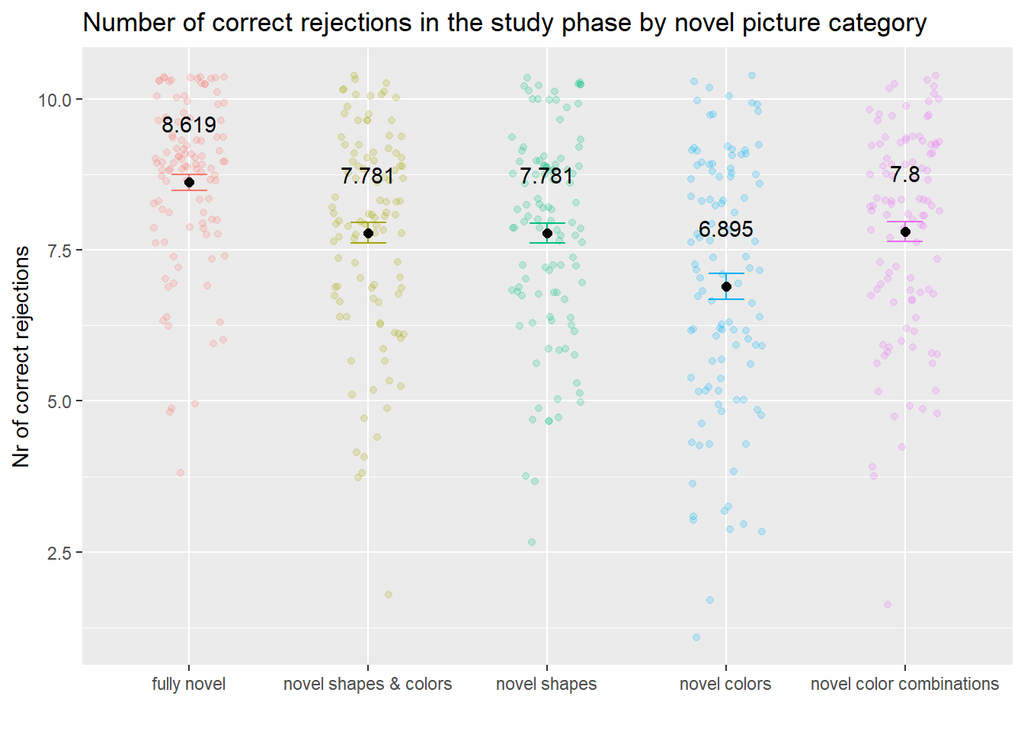

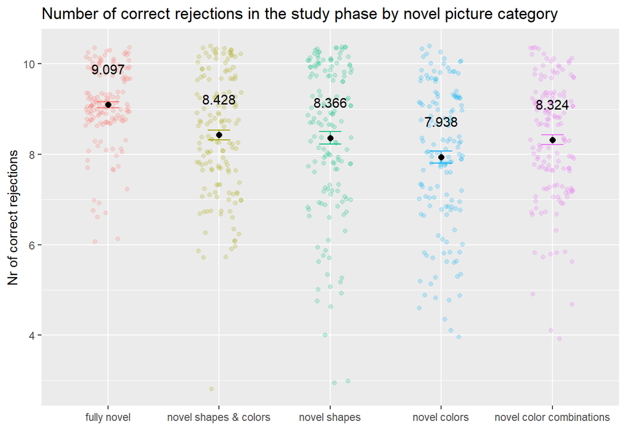

# Test phase:

This phase tests the learning that has occurred during the study phase. If the participants learned the novels in the study phase, their responses should differ for the stimuli that they have already seen during the study phase (familiars) and those that they see for the first time during the test phase (novels).

## ANOVA - Corrected Recog

```
## Converting to factor: stid
```

```
## Contrasts set to contr.sum for the following variables: stid
```

```
## Anova Table (Type 3 tests)
##
## Response: CorrRecog
##          Effect           df  MSE         F   ges p.value
## 1          stid       1, 248 4.59      0.15 <.001    .699
## 2      neworder 3.85, 954.69 3.45 14.35 ***  .041   <.001
## 3 stid:neworder 3.85, 954.69 3.45      1.26  .004    .283
## ---
## Signif. codes:  0 '***' 0.001 '**' 0.01 '*' 0.05 '+' 0.1 ' ' 1
##
## Sphericity correction method: GG
```

```
##  contrast        estimate    SE  df t.ratio p.value
##  A artn - B artn  -0.2000 0.187 248  -1.069  0.9872
##  A artn - C artn   0.4345 0.200 248   2.178  0.4750
##  A artn - D artn   0.1724 0.195 248   0.882  0.9969
##  A artn - E artn   0.7448 0.211 248   3.529  0.0176
##  A artn - A orig  -0.3087 0.193 248  -1.603  0.8455
##  A artn - B orig  -0.2706 0.218 248  -1.238  0.9654
##  A artn - C orig   0.1389 0.228 248   0.608  0.9998
##  A artn - D orig   0.3484 0.237 248   1.472  0.9021
##  A artn - E orig   1.0056 0.234 248   4.289  0.0011
##  B artn - C artn   0.6345 0.212 248   2.996  0.0866
##  B artn - D artn   0.3724 0.214 248   1.744  0.7694
##  B artn - E artn   0.9448 0.224 248   4.222  0.0014
##  B artn - A orig  -0.1087 0.212 248  -0.514  1.0000
##  B artn - B orig  -0.0706 0.236 248  -0.300  1.0000
##  B artn - C orig   0.3389 0.245 248   1.385  0.9309
##  B artn - D orig   0.5484 0.253 248   2.171  0.4794
##  B artn - E orig   1.2056 0.250 248   4.814  0.0001
##  C artn - D artn  -0.2621 0.229 248  -1.145  0.9794
##  C artn - E artn   0.3103 0.233 248   1.334  0.9447
##  C artn - A orig  -0.7432 0.219 248  -3.393  0.0273
##  C artn - B orig  -0.7051 0.242 248  -2.911  0.1080
##  C artn - C orig  -0.2956 0.251 248  -1.177  0.9752
##  C artn - D orig  -0.0860 0.259 248  -0.332  1.0000
##  C artn - E orig   0.5711 0.257 248   2.225  0.4428
##  D artn - E artn   0.5724 0.231 248   2.483  0.2829
##  D artn - A orig  -0.4811 0.225 248  -2.134  0.5054
##  D artn - B orig  -0.4430 0.248 248  -1.786  0.7432
##  D artn - C orig  -0.0335 0.257 248  -0.130  1.0000
##  D artn - D orig   0.1760 0.264 248   0.666  0.9997
##  D artn - E orig   0.8332 0.262 248   3.178  0.0522
##  E artn - A orig  -1.0535 0.224 248  -4.710  0.0002
##  E artn - B orig  -1.0154 0.246 248  -4.121  0.0021
##  E artn - C orig  -0.6059 0.255 248  -2.374  0.3459
##  E artn - D orig  -0.3964 0.263 248  -1.509  0.8878
##  E artn - E orig   0.2608 0.261 248   1.000  0.9920
##  A orig - B orig   0.0381 0.220 248   0.173  1.0000
##  A orig - C orig   0.4476 0.234 248   1.909  0.6629
##  A orig - D orig   0.6571 0.230 248   2.860  0.1227
##  A orig - E orig   1.3143 0.248 248   5.299  <.0001
##  B orig - C orig   0.4095 0.249 248   1.645  0.8243
##  B orig - D orig   0.6190 0.251 248   2.466  0.2921
##  B orig - E orig   1.2762 0.263 248   4.853  0.0001
##  C orig - D orig   0.2095 0.269 248   0.779  0.9988
##  C orig - E orig   0.8667 0.273 248   3.171  0.0533
##  D orig - E orig   0.6571 0.271 248   2.426  0.3152
##
## P value adjustment: tukey method for comparing a family of 10 estimates
```

```
##  contrast  estimate    SE  df t.ratio p.value
##  linear       -9.03  3.43 248  -2.631  0.0091
##  quadratic    -4.31  1.89 248  -2.277  0.0236
##  cubic       -71.28 16.15 248  -4.413  <.0001
##  quartic     -12.64  8.69 248  -1.454  0.1472
##  degree 5     13.13  4.55 248   2.889  0.0042
##  degree 6     -3.04  4.30 248  -0.707  0.4804
```

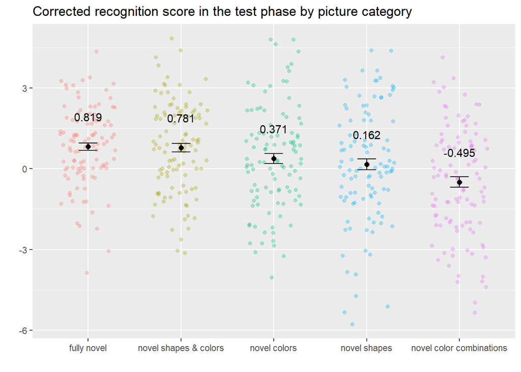

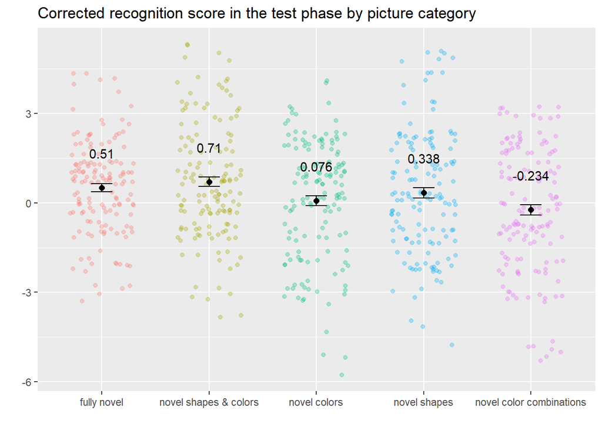

# Mixed models

The metrics

-DTF - Difference To corresponding Familiar picture All pictures are compared to a familiar. The number of differences between the three vectors of the pictures yields a difference score.

-DTAF - mean Difference To All Familiars We calculate the difference from all prototypes and take the mean for each picture in the set.

-DTN - mean Difference To all other Novels in the same category We calculate the differences between each pair of pictures and then take the mean of these differences (19 comparisons per stim).

## Study phase

With these models i tried to assess which difference index explains familiar v novel distinction in study phase the best. As far as i understand, the model with the smallest AIC fits best to our data, which means that the mean difference from the corresponding familiar worked best here. The models all show, that the more different pictures are categorized with the highest efficacy.

```
## Generalized linear mixed model fit by maximum likelihood (Laplace
##   Approximation) [glmerMod]
##  Family: binomial  ( logit )
## Formula: st_corr ~ DTF + stid + (1 | workerId)
##    Data: stlmm
##
##      AIC      BIC   logLik deviance df.resid
##  19291.2  19322.6  -9641.6  19283.2    18746
##
## Scaled residuals:
##     Min      1Q  Median      3Q     Max
## -5.3425  0.2202  0.4580  0.5846  1.2587
##
## Random effects:
##  Groups   Name        Variance Std.Dev.
##  workerId (Intercept) 0.1961   0.4428
## Number of obs: 18750, groups:  workerId, 250
##
## Fixed effects:
##              Estimate Std. Error z value Pr(>|z|)
## (Intercept)  1.017089   0.046388   21.93  < 2e-16 ***
## DTF          0.097608   0.004379   22.29  < 2e-16 ***
## stidorig    -0.314894   0.067427   -4.67 3.01e-06 ***
## ---
## Signif. codes:  0 '***' 0.001 '**' 0.01 '*' 0.05 '.' 0.1 ' ' 1
##
## Correlation of Fixed Effects:
##          (Intr) DTF
## DTF      -0.292
## stidorig -0.623 -0.010
```

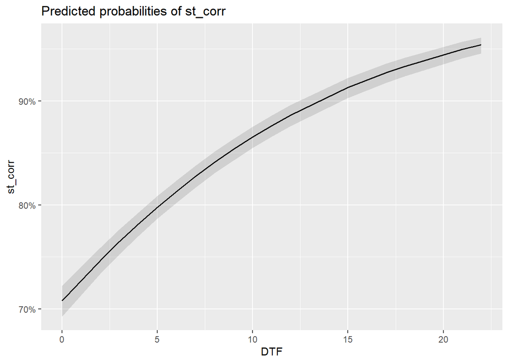

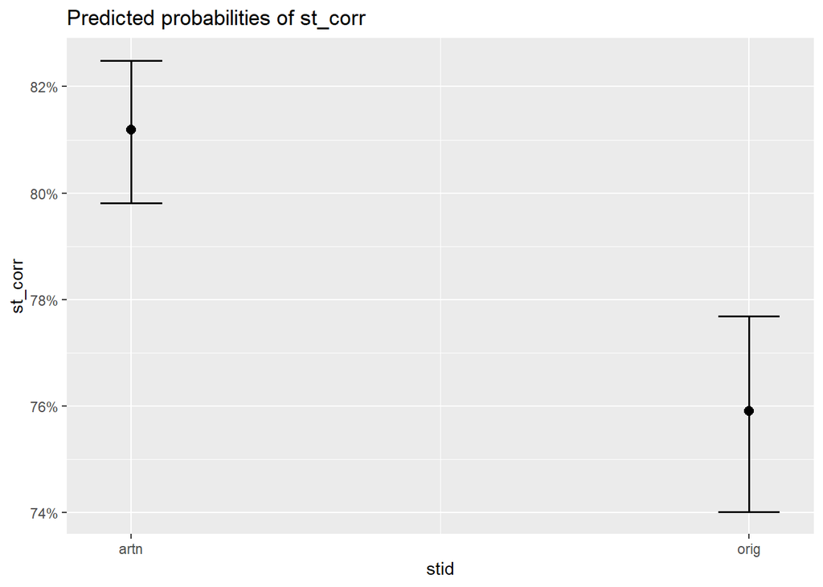

```
## Generalized linear mixed model fit by maximum likelihood (Laplace
##   Approximation) [glmerMod]
##  Family: binomial  ( logit )
## Formula: st_corr ~ DTAF + stid + (1 | workerId)
##    Data: stlmm
##
##      AIC      BIC   logLik deviance df.resid
##  19304.2  19335.6  -9648.1  19296.2    18746
##
## Scaled residuals:
##     Min      1Q  Median      3Q     Max
## -4.0433  0.2956  0.4363  0.5678  1.3603
##
## Random effects:
##  Groups   Name        Variance Std.Dev.
##  workerId (Intercept) 0.1978   0.4447
## Number of obs: 18750, groups:  workerId, 250
##
## Fixed effects:
##              Estimate Std. Error z value Pr(>|z|)
## (Intercept)  0.862898   0.048444  17.812  < 2e-16 ***
## DTAF         0.067343   0.002749  24.499  < 2e-16 ***
## stidorig    -0.315908   0.067666  -4.669 3.03e-06 ***
## ---
## Signif. codes:  0 '***' 0.001 '**' 0.01 '*' 0.05 '.' 0.1 ' ' 1
##
## Correlation of Fixed Effects:
##          (Intr) DTAF
## DTAF     -0.394
## stidorig -0.597 -0.013
```

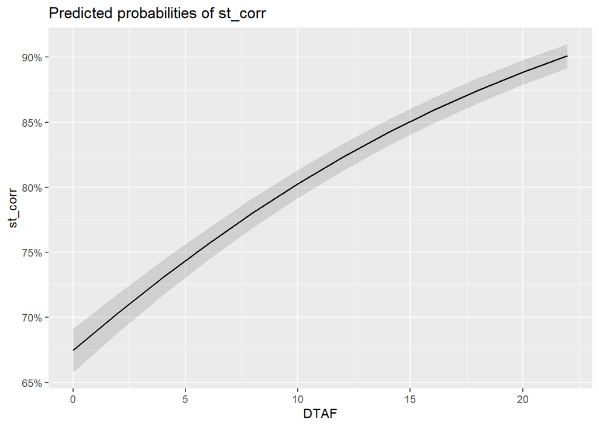

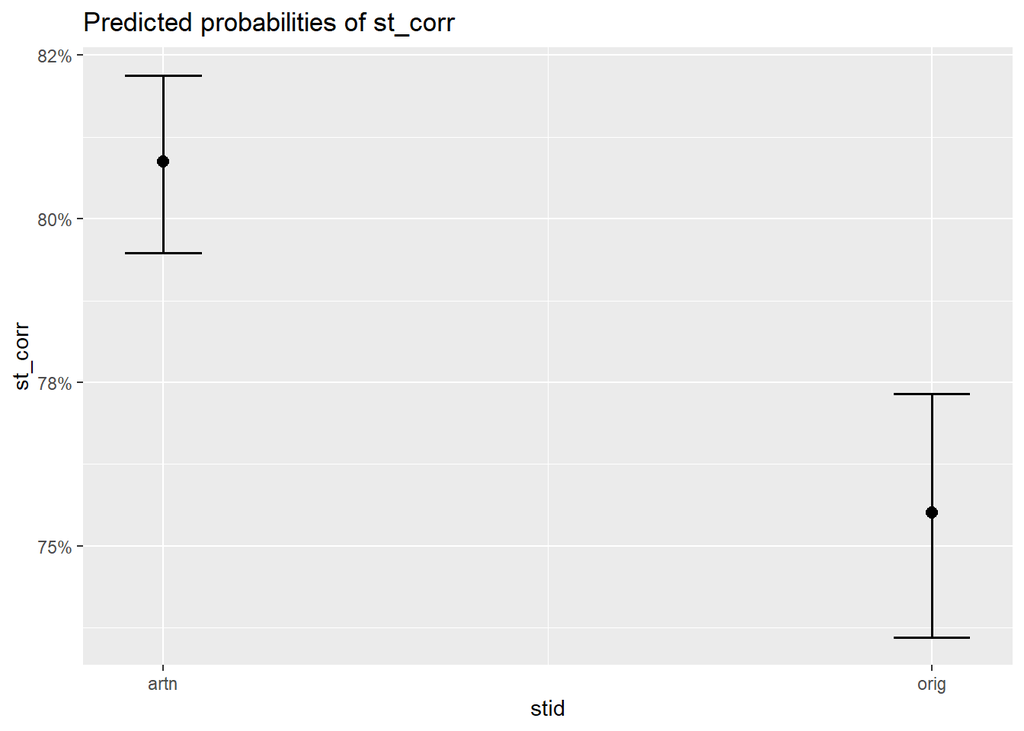

```
## Generalized linear mixed model fit by maximum likelihood (Laplace
##   Approximation) [glmerMod]
##  Family: binomial  ( logit )
## Formula: st_corr ~ DTAN + stid + (1 | workerId)
##    Data: stlmm
##
##      AIC      BIC   logLik deviance df.resid
##  19376.1  19407.5  -9684.1  19368.1    18746
##
## Scaled residuals:
##     Min      1Q  Median      3Q     Max
## -4.1139  0.3153  0.4401  0.5666  1.3440
##
## Random effects:
##  Groups   Name        Variance Std.Dev.
##  workerId (Intercept) 0.196    0.4427
## Number of obs: 18750, groups:  workerId, 250
##
## Fixed effects:
##              Estimate Std. Error z value Pr(>|z|)
## (Intercept)  0.878673   0.048560  18.094  < 2e-16 ***
## DTAN         0.065056   0.002797  23.259  < 2e-16 ***
## stidorig    -0.314686   0.067414  -4.668 3.04e-06 ***
## ---
## Signif. codes:  0 '***' 0.001 '**' 0.01 '*' 0.05 '.' 0.1 ' ' 1
##
## Correlation of Fixed Effects:
##          (Intr) DTAN
## DTAN     -0.406
## stidorig -0.593 -0.013
```

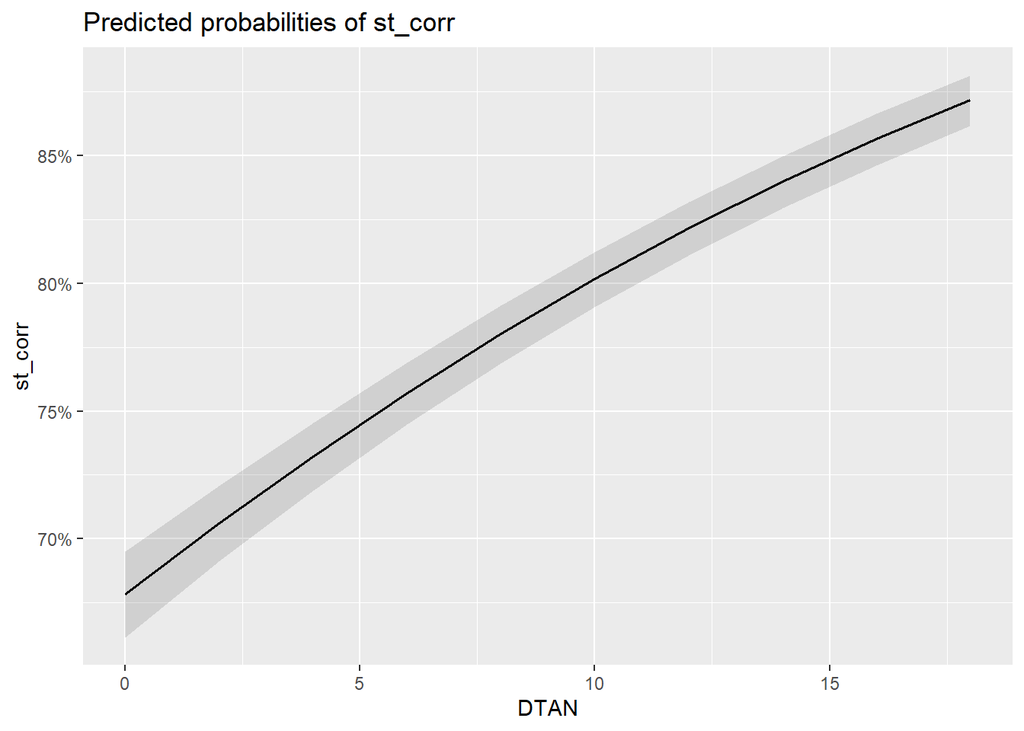

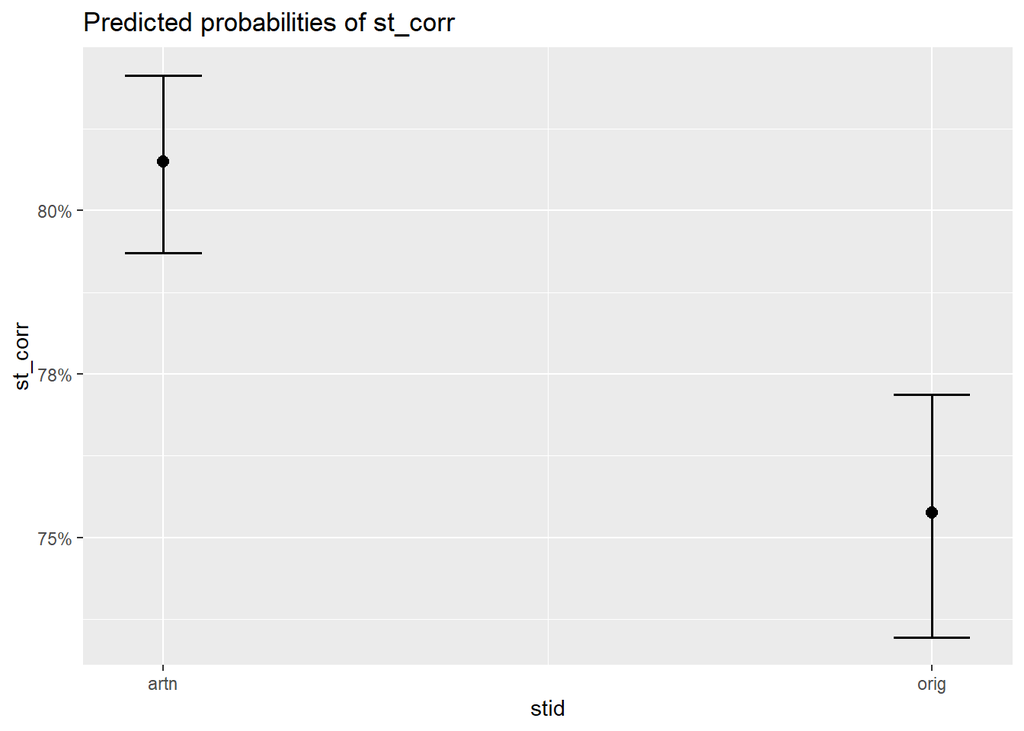

|  | st_corr |  |  |  | st_corr |  |  |  | st_corr |  |  |  |
| --- | --- | --- | --- | --- | --- | --- | --- | --- | --- | --- | --- | --- |
| Predictors | Log-Odds | std. Error | CI | p | Log-Odds | std. Error | CI | p | Log-Odds | std. Error | CI | p |
| (Intercept) | 1.02 | 0.05 | 0.93 – 1.11 | **<0.001** | 0.86 | 0.05 | 0.77 – 0.96 | **<0.001** | 0.88 | 0.05 | 0.78 – 0.97 | **<0.001** |
| DTF | 0.10 | 0.00 | 0.09 – 0.11 | **<0.001** |  |  |  |  |  |  |  |  |
| stid [orig] | -0.31 | 0.07 | -0.45 – -0.18 | **<0.001** | -0.32 | 0.07 | -0.45 – -0.18 | **<0.001** | -0.31 | 0.07 | -0.45 – -0.18 | **<0.001** |
| DTAF |  |  |  |  | 0.07 | 0.00 | 0.06 – 0.07 | **<0.001** |  |  |  |  |
| DTAN |  |  |  |  |  |  |  |  | 0.07 | 0.00 | 0.06 – 0.07 | **<0.001** |
| Random Effects |  |  |  |  |  |  |  |  |  |  |  |  |
| σ<sup>2</sup> | 3.29 |  |  |  | 3.29 |  |  |  | 3.29 |  |  |  |
| τ<sub>00</sub> | 0.20 <sub>workerId</sub> |  |  |  | 0.20 <sub>workerId</sub> |  |  |  | 0.20 <sub>workerId</sub> |  |  |  |
| ICC | 0.06 |  |  |  | 0.06 |  |  |  | 0.06 |  |  |  |
| N | 250 <sub>workerId</sub> |  |  |  | 250 <sub>workerId</sub> |  |  |  | 250 <sub>workerId</sub> |  |  |  |
| Observations | 18750 |  |  |  | 18750 |  |  |  | 18750 |  |  |  |
| Marginal R<sup>2</sup> / Conditional R<sup>2</sup> | 0.081 / 0.133 |  |  |  | 0.059 / 0.112 |  |  |  | 0.051 / 0.105 |  |  |  |
| AIC | 19291.249 |  |  |  | 19304.247 |  |  |  | 19376.102 |  |  |  |
| AICc | 19291.251 |  |  |  | 19304.249 |  |  |  | 19376.104 |  |  |  |

## Test phase

### Models #1 - without random slope term

Logistic mixed regression for the test phase. Does difference from prototypes or familiarity/novelty have an effect on correct categorization in the test phase?

```
## Generalized linear mixed model fit by maximum likelihood (Laplace
##   Approximation) [glmerMod]
##  Family: binomial  ( logit )
## Formula: rt_resp ~ DTF * tq + stid + (1 | workerId)
##    Data: tdlmm
##
##      AIC      BIC   logLik deviance df.resid
##  25873.9  25921.5 -12931.0  25861.9    20710
##
## Scaled residuals:
##     Min      1Q  Median      3Q     Max
## -2.1416 -0.7864 -0.4942  0.9689  5.1095
##
## Random effects:
##  Groups   Name        Variance Std.Dev.
##  workerId (Intercept) 0.3291   0.5737
## Number of obs: 20716, groups:  workerId, 250
##
## Fixed effects:
##              Estimate Std. Error z value Pr(>|z|)
## (Intercept)  0.326259   0.061727   5.286 1.25e-07 ***
## DTF         -0.117615   0.004951 -23.757  < 2e-16 ***
## tqold       -0.182996   0.050383  -3.632 0.000281 ***
## stidorig    -0.147856   0.079974  -1.849 0.064485 .
## DTF:tqold    0.042983   0.006518   6.594 4.27e-11 ***
## ---
## Signif. codes:  0 '***' 0.001 '**' 0.01 '*' 0.05 '.' 0.1 ' ' 1
##
## Correlation of Fixed Effects:
##           (Intr) DTF    tqold  stidrg
## DTF       -0.489
## tqold     -0.445  0.598
## stidorig  -0.538  0.001  0.001
## DTF:tqold  0.371 -0.757 -0.801 -0.001
```

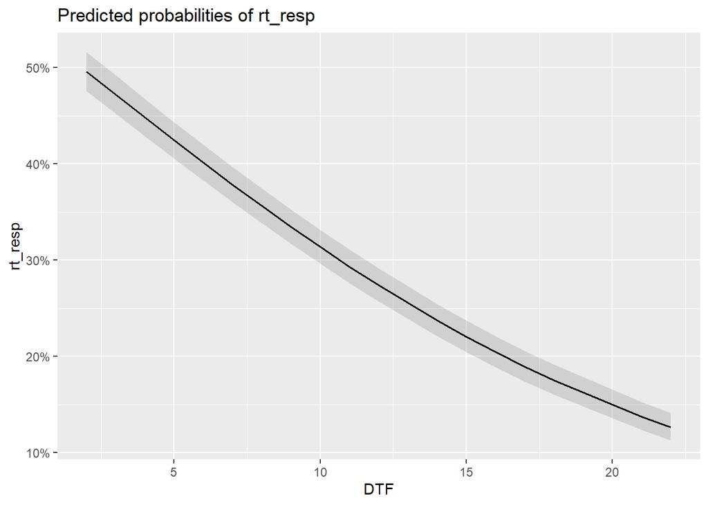

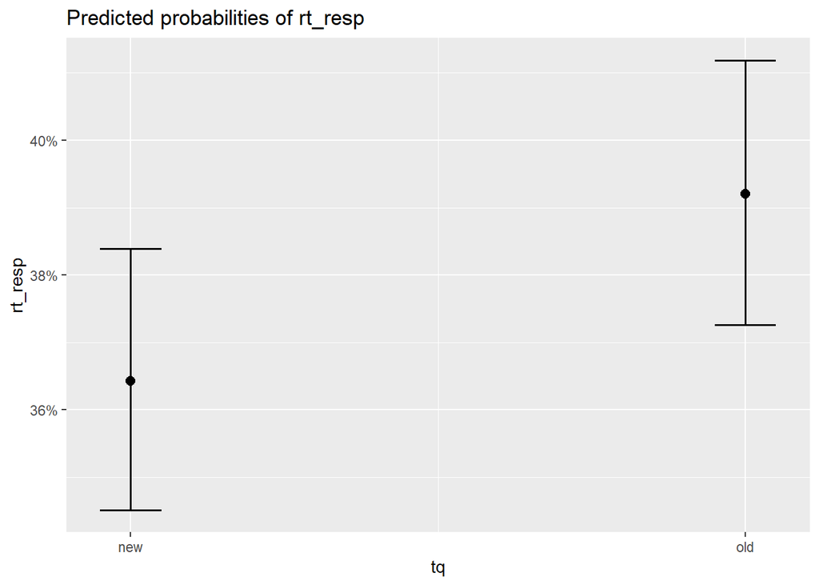

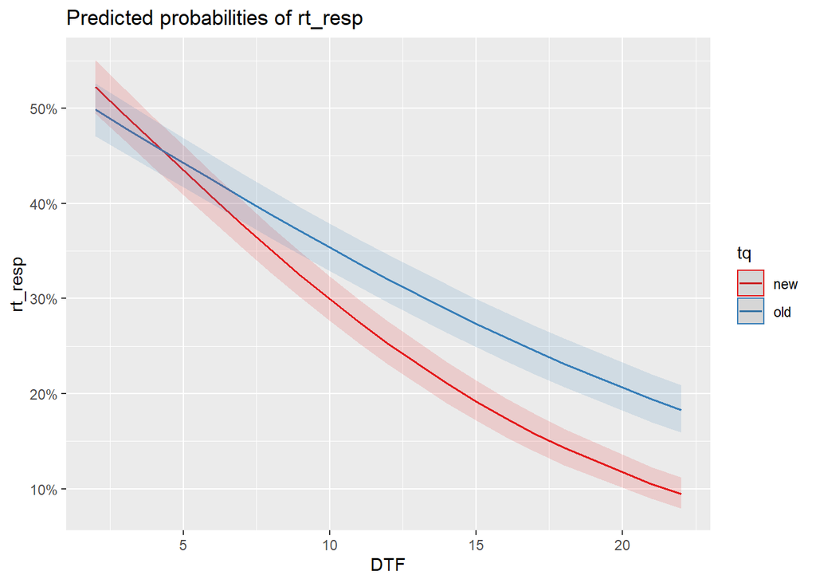

```
## Generalized linear mixed model fit by maximum likelihood (Laplace
##   Approximation) [glmerMod]
##  Family: binomial  ( logit )
## Formula: rt_resp ~ DTAF * tq + stid + (1 | workerId)
##    Data: tdlmm
##
##      AIC      BIC   logLik deviance df.resid
##  25912.5  25960.2 -12950.3  25900.5    20710
##
## Scaled residuals:
##     Min      1Q  Median      3Q     Max
## -2.0741 -0.7902 -0.4982  0.9700  4.1581
##
## Random effects:
##  Groups   Name        Variance Std.Dev.
##  workerId (Intercept) 0.3269   0.5718
## Number of obs: 20716, groups:  workerId, 250
##
## Fixed effects:
##              Estimate Std. Error z value Pr(>|z|)
## (Intercept)  2.079856   0.120224  17.300  < 2e-16 ***
## DTAF        -0.197260   0.008549 -23.073  < 2e-16 ***
## tqold       -0.598959   0.148918  -4.022 5.77e-05 ***
## stidorig    -0.149646   0.079738  -1.877   0.0606 .
## DTAF:tqold   0.054194   0.011571   4.684 2.82e-06 ***
## ---
## Signif. codes:  0 '***' 0.001 '**' 0.01 '*' 0.05 '.' 0.1 ' ' 1
##
## Correlation of Fixed Effects:
##            (Intr) DTAF   tqold  stidrg
## DTAF       -0.895
## tqold      -0.671  0.720
## stidorig   -0.277  0.002  0.002
## DTAF:tqold  0.659 -0.736 -0.979 -0.002
## optimizer (Nelder_Mead) convergence code: 0 (OK)
## Model failed to converge with max|grad| = 0.00414651 (tol = 0.002, component 1)
```

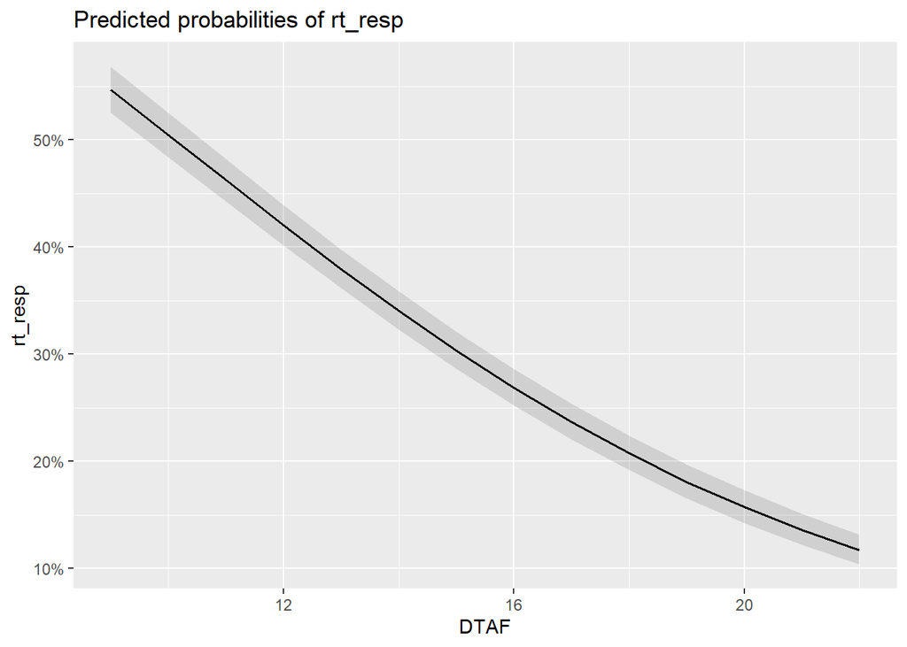

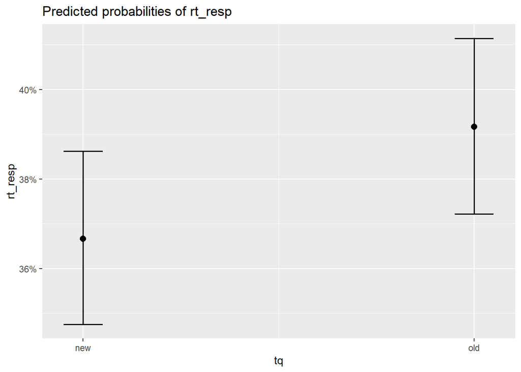

```
## Data were 'prettified'. Consider using `terms="DTAF [all]"` to get smooth plots.
```

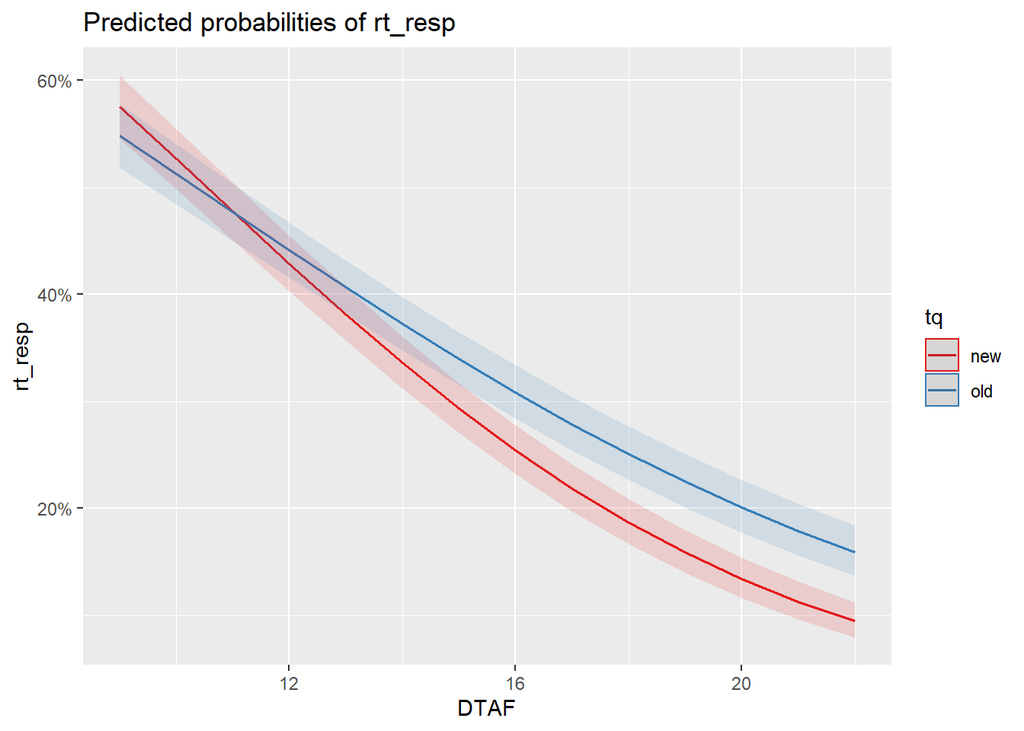

```
## Generalized linear mixed model fit by maximum likelihood (Laplace
##   Approximation) [glmerMod]
##  Family: binomial  ( logit )
## Formula: rt_resp ~ DTAN * tq + stid + (1 | workerId)
##    Data: tdlmm
##
##      AIC      BIC   logLik deviance df.resid
##  26067.2  26114.8 -13027.6  26055.2    20710
##
## Scaled residuals:
##     Min      1Q  Median      3Q     Max
## -2.1872 -0.7827 -0.5230  0.9819  4.6787
##
## Random effects:
##  Groups   Name        Variance Std.Dev.
##  workerId (Intercept) 0.3237   0.5689
## Number of obs: 20716, groups:  workerId, 250
##
## Fixed effects:
##             Estimate Std. Error z value Pr(>|z|)
## (Intercept)  2.92294    0.16275  17.960  < 2e-16 ***
## DTAN        -0.26532    0.01219 -21.770  < 2e-16 ***
## tqold       -0.71466    0.21378  -3.343 0.000829 ***
## stidorig    -0.15192    0.07936  -1.914 0.055565 .
## DTAN:tqold   0.06490    0.01674   3.877 0.000106 ***
## ---
## Signif. codes:  0 '***' 0.001 '**' 0.01 '*' 0.05 '.' 0.1 ' ' 1
##
## Correlation of Fixed Effects:
##            (Intr) DTAN   tqold  stidrg
## DTAN       -0.945
## tqold      -0.691  0.717
## stidorig   -0.205  0.003  0.003
## DTAN:tqold  0.686 -0.726 -0.990 -0.003
## optimizer (Nelder_Mead) convergence code: 0 (OK)
## Model failed to converge with max|grad| = 0.00245942 (tol = 0.002, component 1)
```

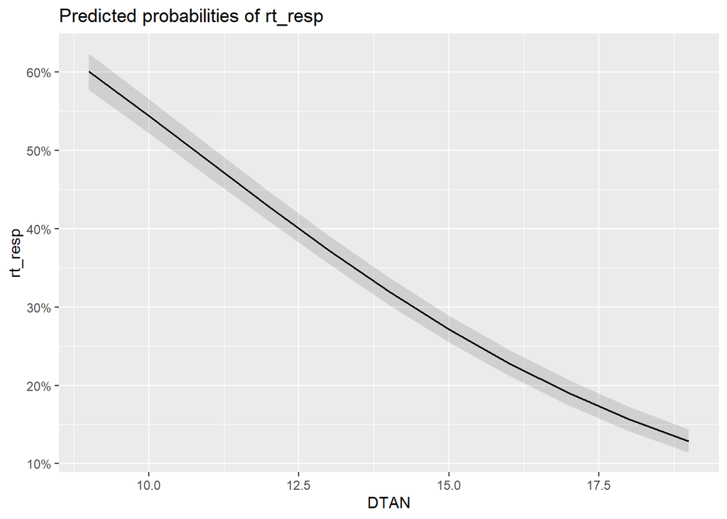

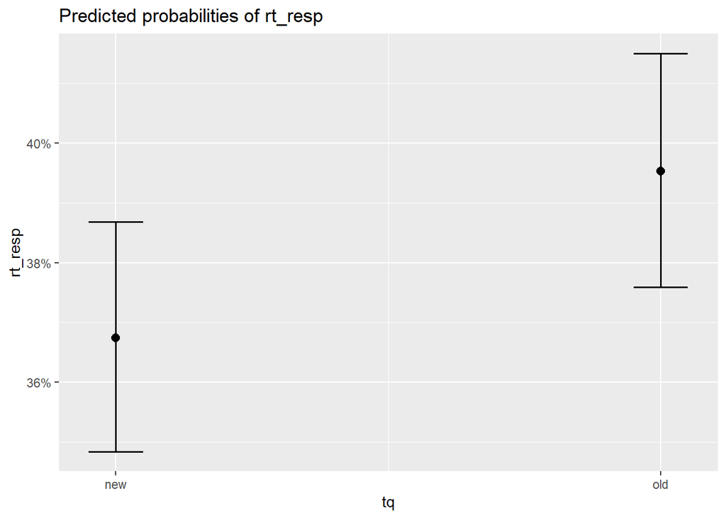

```
## Data were 'prettified'. Consider using `terms="DTAN [all]"` to get smooth plots.
```

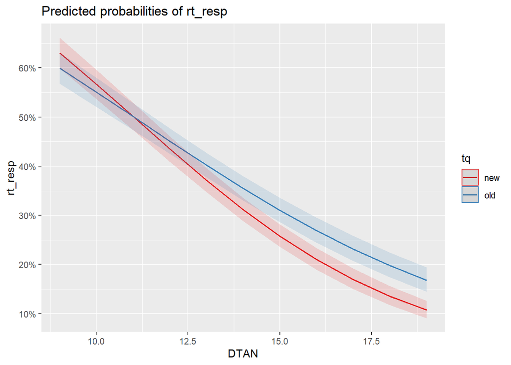

|  | rt_resp |  |  |  | rt_resp |  |  |  | rt_resp |  |  |  |
| --- | --- | --- | --- | --- | --- | --- | --- | --- | --- | --- | --- | --- |
| Predictors | Log-Odds | std. Error | CI | p | Log-Odds | std. Error | CI | p | Log-Odds | std. Error | CI | p |
| (Intercept) | 0.33 | 0.06 | 0.21 – 0.45 | **<0.001** | 2.08 | 0.12 | 1.84 – 2.32 | **<0.001** | 2.92 | 0.16 | 2.60 – 3.24 | **<0.001** |
| DTF | -0.12 | 0.00 | -0.13 – -0.11 | **<0.001** |  |  |  |  |  |  |  |  |
| tq [old] | -0.18 | 0.05 | -0.28 – -0.08 | **<0.001** | -0.60 | 0.15 | -0.89 – -0.31 | **<0.001** | -0.71 | 0.21 | -1.13 – -0.30 | **0.001** |
| stid [orig] | -0.15 | 0.08 | -0.30 – 0.01 | 0.064 | -0.15 | 0.08 | -0.31 – 0.01 | 0.061 | -0.15 | 0.08 | -0.31 – 0.00 | 0.056 |
| DTF * tq [old] | 0.04 | 0.01 | 0.03 – 0.06 | **<0.001** |  |  |  |  |  |  |  |  |
| DTAF |  |  |  |  | -0.20 | 0.01 | -0.21 – -0.18 | **<0.001** |  |  |  |  |
| DTAF * tq [old] |  |  |  |  | 0.05 | 0.01 | 0.03 – 0.08 | **<0.001** |  |  |  |  |
| DTAN |  |  |  |  |  |  |  |  | -0.27 | 0.01 | -0.29 – -0.24 | **<0.001** |
| DTAN * tq [old] |  |  |  |  |  |  |  |  | 0.06 | 0.02 | 0.03 – 0.10 | **<0.001** |
| Random Effects |  |  |  |  |  |  |  |  |  |  |  |  |
| σ<sup>2</sup> | 3.29 |  |  |  | 3.29 |  |  |  | 3.29 |  |  |  |
| τ<sub>00</sub> | 0.33 <sub>workerId</sub> |  |  |  | 0.33 <sub>workerId</sub> |  |  |  | 0.32 <sub>workerId</sub> |  |  |  |
| ICC | 0.09 |  |  |  | 0.09 |  |  |  | 0.09 |  |  |  |
| N | 250 <sub>workerId</sub> |  |  |  | 250 <sub>workerId</sub> |  |  |  | 250 <sub>workerId</sub> |  |  |  |
| Observations | 20716 |  |  |  | 20716 |  |  |  | 20716 |  |  |  |
| Marginal R<sup>2</sup> / Conditional R<sup>2</sup> | 0.075 / 0.159 |  |  |  | 0.070 / 0.154 |  |  |  | 0.055 / 0.140 |  |  |  |
| AIC | 25873.913 |  |  |  | 25912.535 |  |  |  | 26067.191 |  |  |  |
| AICc | 25873.917 |  |  |  | 25912.539 |  |  |  | 26067.195 |  |  |  |